# Analyzing the Trichopetra data set with the Poisson log-normal LDA model

Julien Chiquet

2018-07-09

This vignette intends to illustrate the basical use of the `PLNLDA` function and the methods accompaning the R6 Class `PLNLDAfit`. To this end, let us consider an ecological data set concerning abundances of Trichopetera species, coupled with some meteological factors that may influence the presence their presence.

## The Trichoptera data set

This data set comes with the `R` package *ade4*. We also load our own package for the upcoming analyses:

```r
library(PLNmodels)
library(ade4)
data("trichometeo")
```

The insects have been trapped between 1959 and 1960 during 49 trapping nights. These trapping nights are the observations in the case at hand. For each one of these, the abundance of 17 Trichoptera species is recorded, which forms the first table:

```r
dim(trichometeo$fau)
```

```
## [1] 49 17
```

```r
head(trichometeo$fau)
```

```
##   Che Hyc Hym Hys Psy Aga Glo Ath Cea Ced Set All Han Hfo Hsp Hve Sta
## 1   0   0   5   0  17   0   0   0   0   2   0   1   0   1   2   0   1
## 2   0   0   3   0   8   0   0   0   0   0   0   2   0   0   0   0   0
## 3   0   0   1   0  32   0   0   0   0   0   0   4   0   0   1   0   0
## 4   0   0   3   0 176   4   0   0   0   1   0   3   0   0   3   0   2
## 5   0   0   4   0  69   2   0   0   0   0   0   1   0   0   1   0   2
## 6   0   0   2   0  14   1   0   0   0   0   0   1   0   0   0   0   0
```

The second table concerns 11 meteorological variables which may influence the abundance of each species:

```r
dim(trichometeo$meteo)
```

```
## [1] 49 11
```

```r
head(trichometeo$meteo)
```

```
##   T.max T.soir T.min Vent Pression Var.Pression Humidite Nebu.Nuit
## 1  22.2   18.7  11.0 -2.3    998.5          4.1       60        19
## 2  24.2   19.8   8.4 -2.7    999.5         -1.1       63         0
## 3  27.4   22.0  11.0 -0.7    997.2         -3.6       73         6
## 4  29.0   23.0  12.6  2.3    991.1         -6.2       71        81
## 5  28.2   22.5  12.0  2.3    990.1          1.7       62        50
## 6  28.0   23.9  13.8 -2.0    990.1         -0.8       64        50
##   Precip.Nuit Nebu.Moy Precip.Tot
## 1           0       17          0
## 2           0       27          0
## 3           0       13          0
## 4           0       52          0
## 5           0       34          0
## 6           0       36          0
```

Finally, the observations (that is to say, the trapping nights), have been classified into 12 groups corresponding to contiguous nights between summer 1959 and summer 1960.

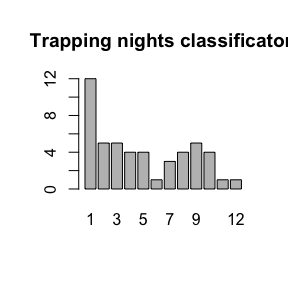

```r
barplot(table(trichometeo$cla), main="Trapping nights classificaton")
```

A full description of the data set (in French) is available [at this page](http://pbil.univ-lyon1.fr/R/pdf/pps034.pdf).

### A discriminant analysis for the Trichopetra data set

We start by adjusting the above model to Trichoptera data set. Here, the matrix of observations $\mathbf{Y}$ corresponds to the abundance of each species in each trapping night. The classification corresponds to the consecutive night groups caught. The model can be fitted with the function `PLNLDA` as follows:

```r
abundance <- as.matrix(trichometeo$fau) ## must be a matrix
night_grp <- as.factor(trichometeo$cla)
myLDA_nocov <- PLNLDA(abundance, grouping = night_grp)
```

```
##
##  Initialization...
##  Adjusting the standard PLN model.
##  Performing Discriminant Analysis...
##  DONE!
```

The `myLDA_nocov` variable is an `R6` object with class `PLNLDAfit`, which comes with a couple of methods, as recalled when printing such an object:

```r
myLDA_nocov
```

```
## Linear Discriminant Analysis for Poisson Lognormal distirbution
## ==================================================================
##  degrees_freedom R_squared
##              391        NA
## ==================================================================
## * Useful fields
##   $model_par, $var_par, $loglik, $BIC, $ICL, $degrees_freedom, $criteria
## * Useful methods
##     $plot(), $predict()
## * Additional fields for LDA
##     $percent_var, $corr_circle, $scores
## * Additional methods for LDA
##     $plot_LDA(), $plot_correlation_circle(), $plot_individual_map()
```

Essentially, the most important methodis the `plot` method: we separate well the different groups

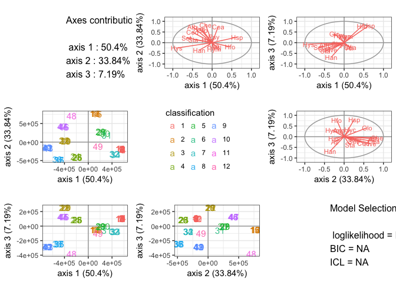

```r
myLDA_nocov$plot_LDA()
```

### Accounting for other covariates

It is possible (experimental) to correct for other covariates before finding the LDA axis that separate well the grouping :

```r
abundance <- as.matrix(trichometeo$fau) ## must be a matrix
night_grp <- as.factor(trichometeo$cla) ## must be a factor
covariates <- as.matrix(trichometeo$meteo) ## must be a matrix
myLDA_cov <- PLNLDA(abundance, night_grp, covariates)
```

```
##
##  Initialization...
##  Adjusting the standard PLN model.
##  Performing Discriminant Analysis...
##  DONE!
```

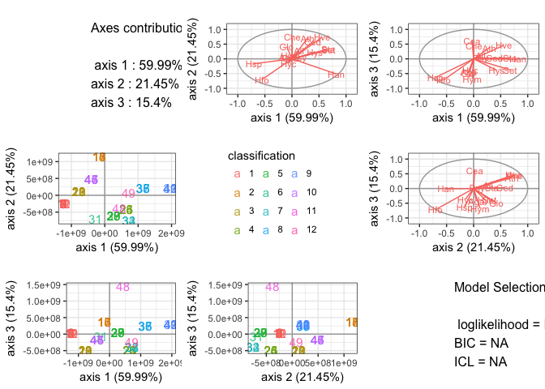

```r
myLDA_cov$plot_LDA()
```